# Intervaly spolehlivosti

Kateřina Večerková vecerkok@vscht.cz

2025-07-03

# Intervaly spolehlivosti

## 1. **Úvod do intervalů spolehlivosti**

- **Co je interval spolehlivosti (CI)?**
  - Interval spolehlivosti udává rozmezí hodnot, které s určitou mírou spolehlivosti (např. 95 %) pravděpodobně obsahuje populační parametr (např. průměr).
  - Namísto jednoho bodového odhadu poskytuje intervalový odhad.
- **Proč jsou intervaly spolehlivosti užitečné?**
  - Zohledňují variabilitu vzorkování.
  - Poskytují více informací než bodový odhad, protože ukazují přesnost odhadu.
  - Čím širší je interval, tím méně přesný je odhad, ale tím vyšší je jistota; čím užší interval, tím větší přesnost, ale menší jistota.

## 2. **Intervaly spolehlivosti pro průměr**

- **Případ 1: Velké vzorky (n > 30, Z-statistika)**
  - Pokud je velikost vzorku velká (n > 30), používá se **Z-statistika** k výpočtu CI pro průměr.
  - **Vzorec**:
    $$CI = \bar{x} \pm Z_{\alpha/2} \times \left(\frac{s}{\sqrt{n}}\right)$$
    - $\bar{x}$ = průměr výběru
    - $Z_{\alpha/2}$ = kritická hodnota Z pro požadovanou úroveň spolehlivosti (např. 1.96 pro 95% CI)
    - $s$ = směrodatná odchylka výběru
    - $n$ = velikost výběru
  - **Příklad v R:**

```r
# Interval spolehlivosti pro n > 30
x <- rnorm(100, mean = 100, sd = 15)
n <- length(x)
x_bar <- mean(x)
z <- qnorm(0.975)  # pro 95% úroveň spolehlivosti
se <- sd(x) / sqrt(n)
lower <- x_bar - z * se
upper <- x_bar + z * se
c(lower, upper)
```

```
## [1] 100.6570 106.6678
```

- **Případ 2: Malé vzorky (n < 30, t-statistika)**
  - Pro malé velikosti vzorku (n < 30) se místo Z-statistiky používá **t-statistika**.
  - **Vzorec**:

  $$CI = \bar{x} \pm t_{\alpha/2, df} \times \left(\frac{s}{\sqrt{n}}\right)$$
  - $t_{\alpha/2, df}$ = kritická hodnota t (závisí na hladině spolehlivosti a stupních volnosti, df = n - 1)
  - Ostatní symboly jsou stejné jako u velkých vzorků.
  - **Příklad v R:**

```r
# Interval spolehlivosti pro n < 30
x <- rnorm(20, mean = 100, sd = 15)
n <- length(x)
x_bar <- mean(x)
t_stat <- qt(0.975, df = n - 1)
se <- sd(x) / sqrt(n)
lower <- x_bar - t_stat * se
upper <- x_bar + t_stat * se
c(lower, upper)
```

```
## [1]  93.64409 106.70523
```

## 3. **Interpretace intervalů spolehlivosti**

- **Jak interpretovat interval spolehlivosti**:
  - 95% interval spolehlivosti znamená: „S 95% jistotou můžeme říci, že skutečný populační průměr leží v tomto intervalu.“
    - **Příklad**: Pokud je CI pro průměrnou výšku populace [165, 175], znamená to, že s 95% jistotou odhadujeme, že skutečný průměr výšky se nachází mezi 165 a 175 cm.
- **Důležité poznámky**:
  - **Širší intervaly** značí větší nejistotu.
  - **Užší intervaly** značí větší přesnost.

## 4. **Vizualizace intervalů spolehlivosti**

- **Vykreslování CI v R**:
  - Vizualizace CI pomáhá pochopit nejistotu spojenou s bodovým odhadem.
  - Příklad: Bootstrapping intervalů spolehlivosti pro průměry vzorků.

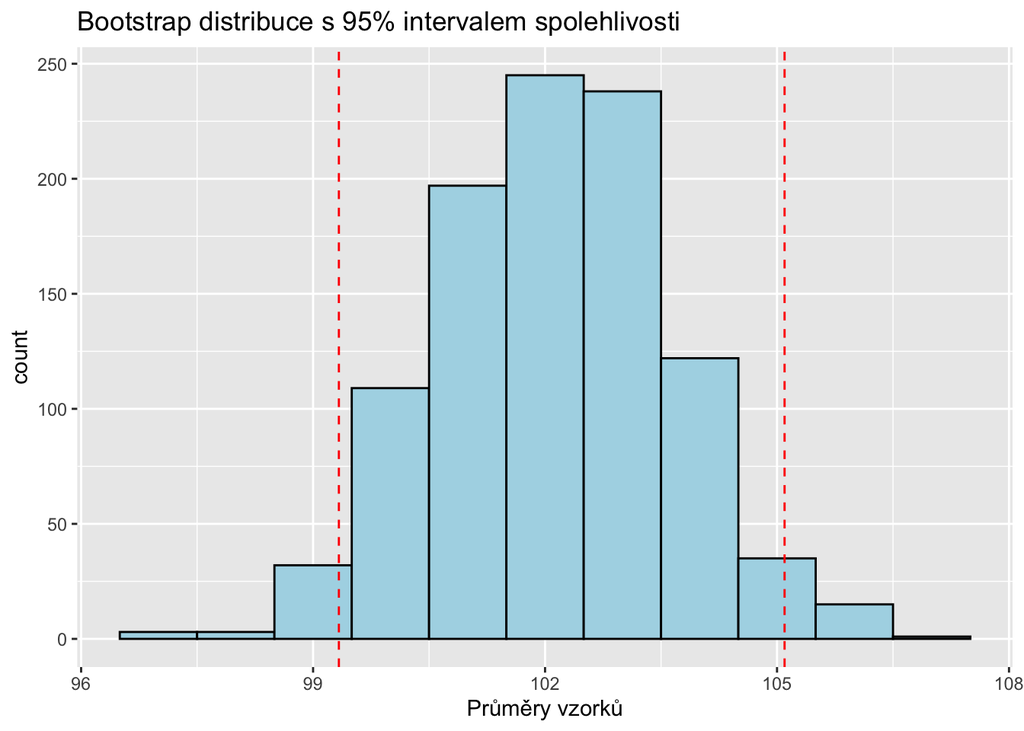

```r
library(ggplot2, quiet=TRUE)
# Vzorek dat a výpočet CI
x <- rnorm(100, mean = 100, sd = 15)
boot_means <- replicate(1000, mean(sample(x, size = 100, replace = TRUE)))
ci <- quantile(boot_means, c(0.025, 0.975))

# Vizualizace CI
ggplot(data.frame(x = boot_means), aes(x = x)) +
 geom_histogram(binwidth = 1, fill = "lightblue", color = "black") +
 geom_vline(xintercept = ci, color = "red", linetype = "dashed") +
 labs(title = "Bootstrap distribuce s 95% intervalem spolehlivosti", x = "Průměry vzorků")
```

## 5. **Slovník pojmů**

| **Anglický pojem** | **Český překlad** | **Vysvětlení** |
| --- | --- | --- |
| Confidence Interval (CI) | Interval spolehlivosti | Rozmezí hodnot, které s určitou pravděpodobností obsahuje skutečný populační parametr. |
| Confidence Level | Úroveň spolehlivosti | Procento, které udává, jak často skutečný parametr leží v intervalu (např. 95 %). |
| Significance Level ($\alpha$) | Hladina významnosti ($\alpha$) | Pravděpodobnost, že zamítneme nulovou hypotézu, i když je pravdivá. Pro CI platí $\alpha = 1 - \text{úroveň spolehlivosti}$. |
| Sample Mean ($\bar{x}$) | Průměr výběru | Průměr hodnot z výběru, použitý jako bodový odhad populačního průměru. |
| Standard Error (SE) | Standardní chyba | Směrodatná odchylka rozdělení průměru vzorků. |
| Z-statistic | Z-statistika | Používá se pro velké vzorky (n > 30) při výpočtu CI. |
| t-statistic | t-statistika | Používá se pro malé vzorky (n < 30) při výpočtu CI. |
| Sample Size (n) | Velikost výběru | Počet pozorování ve vzorku. |
| Population Parameter | Populační parametr | Hodnota (např. průměr), kterou se snažíme odhadnout z výběru. |
| Margin of Error | Chyba odhadu | Hodnota přičtená a odečtená od bodového odhadu pro vytvoření intervalu. |
| Degrees of Freedom (df) | Stupně volnosti | U t-rozdělení platí df = n - 1, kde n je velikost vzorku. |
| Critical Value | Kritická hodnota | Hodnota ze Z- nebo t-rozdělení, která určuje velikost chyby odhadu. |

# Závěr

- Intervaly spolehlivosti nám dávají rozmezí, ve kterém se pravděpodobně nachází skutečný populační parametr.
- Pro velké vzorky používáme Z-statistiku, pro malé vzorky t-statistiku.
- Šířka intervalu závisí na velikosti vzorku, úrovni spolehlivosti a variabilitě dat.